# Predict OVCA Subtypes

aedin culhane

2016-07-14

```r
datadir = "../data"
srcdir= "../R"
source(file.path(srcdir, "ovca.R"))

library(made4)
library(curatedOvarianData)
library(caret)
```

## The TCGA molecular subtypes

The TCGA study (“Comprehensive Molecular Portraits of Human Breast Tumours” 2012) have described four high grade serous ovarian cancer molecular subtypes which are correlated to following the AOCS subtypes;

```
-------     -----------
  AOCS      TCGA
------      ------------
  C1        mesenchymal
  C2        immunoreative
  C4        differentiated *
  C5        proliferative
------      --------------

 * Note, C4 also correlated to immunoreative.
```

We downloaded a 100 gene signature of the TCGA molecular subtypes which was published as Supplementary Table 7 in the research article by Verhaak et al (Verhaak et al. 2013)

Of these 100 genes, 90 were in the Bioconductor curatedOvarianData TCGA_eset (Ganzfried et al. 2013)

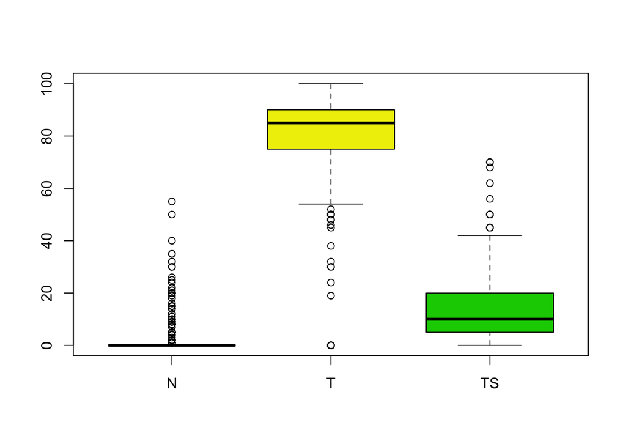

```r
require(curatedOvarianData)
data("TCGA_eset")

# Read TCGA 100 Gene Signature
tcgaGenes<-read.table(file.path(datadir,"23257362","Verhaak_13_CLOVAR100_Subtype.csv"), header=TRUE,  sep=",", as.is=TRUE)

boxplot(cbind(TCGA_eset$percent_normal_cells, TCGA_eset$percent_tumor_cells,TCGA_eset$percent_stromal_cells), ylim=c(0,100), names=c("N", "T", "TS"), col=c("grey", "yellow2", "green3"))
```

```r
## Read the predicted subtypes of datasets
tcgaAnnotSubtypes<-read.table(file.path(datadir,"23257362", "Verhaak_13_suppl_SupplTab1.csv"), header=TRUE,  sep=",", skip=1, as.is=TRUE)
#table(tcgaAnnotSubtypes$DATASET)



# Filter the TCGA genes to those present in the curatedOVarianData TCGA_eset
print("Number of TCGA genes in the curatedOVarianData eset")
```

```
## [1] "Number of TCGA genes in the curatedOVarianData eset"
```

```r
print(table(tcgaGenes[,1]%in%featureNames(TCGA_eset)))
```

```
##
## FALSE  TRUE
##    10    90
```

```r
tcgaGenes<-tcgaGenes[tcgaGenes[,1]%in%featureNames(TCGA_eset),]
```

The TCGA_eSet in the curated ovarian data contained 578 samples. Among these, 488 were in the discovery set, and we knew the tumor TCGA subtype classification.

```r
## Short code to compare the annotation of the 489 discovery subset from the first and second TCGA papers
## TCGA_489_UE.k4.txt was emailed by Roel Verhaak with the subtypes from the first TCGA paper

# Read TCGA tumor subtypes from the first TCGA paper.
tcgaSubtypesPaper1<-read.table(file.path(datadir,"23257362", "TCGA_489_UE.k4.txt"), sep="\t", header=TRUE, as.is=TRUE)

## Create a vector of the shortened Sample ID
tcgaSubtypesPaper1[,3]<-sub("-01[A,B,C,D]-0[1,2,3]R$", "", gsub("\\.", "\\-", tcgaSubtypesPaper1[,1]))
rownames(tcgaSubtypesPaper1) = tcgaSubtypesPaper1[,3]

tcgaAnnotSubtypes<-read.table(file.path(datadir,"23257362", "Verhaak_13_suppl_SupplTab1.csv"), header=TRUE,  sep=",", skip=1, as.is=TRUE)
#table(tcgaAnnotSubtypes$DATASET)

tt2<-tcgaAnnotSubtypes[grep("TCGA-discover",tcgaAnnotSubtypes$DATASET),]
rownames(tt2) = tt2$ID
TCGA_eset$SUBTYPE= tt2[TCGA_eset$unique_patient_ID,]$SUBTYPE
TCGA_eset$DATASET = "Validation"
TCGA_eset$DATASET[TCGA_eset$unique_patient_ID %in% tt2$ID]  ="DISCOVERY"

## Rownames are the same
#comparelists(rownames(tt2), rownames(tt1))
tcgaSubtypesPaper1<-tcgaSubtypesPaper1[rownames(tt2),]

## All TRUE, good annotation has not changed
if (!identical(tcgaSubtypesPaper1$k4, tt2$SUBTYPE)) print("TCGA annotation issue")
```

```r
#TCGA_eset[tcgaGenes[,1],]
table(TCGA_eset$DATASET,TCGA_eset$SUBTYPE)
```

```
##
##              Differentiated Immunoreactive Mesenchymal Proliferative
##   DISCOVERY             135            106         109           138
##   Validation              0              0           0             0
```

```r
heatplot(TCGA_eset[as.character(tcgaGenes[,1]),], classvec=TCGA_eset$SUBTYPE,classvecCol =c("gray80", "grey20", "navy", "cyan"))
```

```
## [1] "Data (original) range:  2.31 13.07"
## [1] "Data (scale) range:  -6.87 8.87"
## [1] "Data scaled to range:  -3 3"
##      Class            Color
## [1,] "Differentiated" "gray80"
## [2,] "Immunoreactive" "grey20"
## [3,] "Mesenchymal"    "navy"
## [4,] "Proliferative"  "cyan"
```

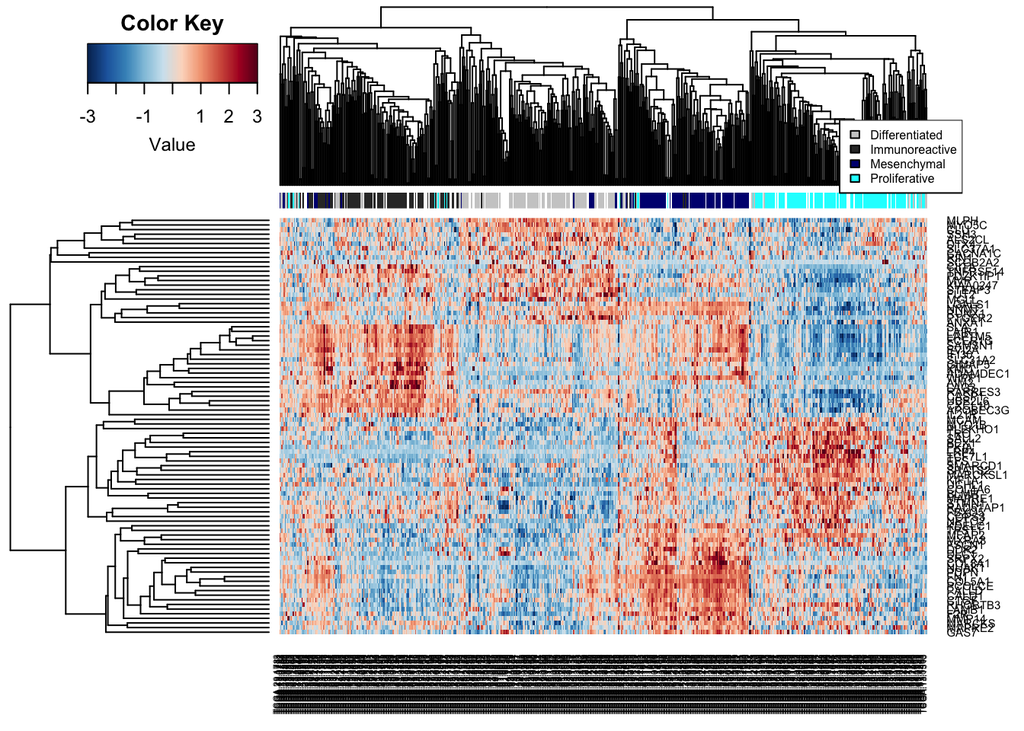

```r
legend("topright", legend=levels(factor(TCGA_eset$SUBTYPE)), fill=c("gray80", "grey20", "navy", "cyan"), cex=0.5)
```

One of the samples in the Verhaak annotation was missing in TCGA_eSet.“TCGA-13-0760” is absent in the curatedOvarianData package. There are also 2 other samples (“TCGA-61-2611”, “TCGA-61-2610” ) listed in the validation set that are missing.

```r
table(tcgaAnnotSubtypes[tcgaAnnotSubtypes[,1]%in%TCGA_eset$unique_patient_ID, "DATASET"])
```

```
##
##  TCGA-discovery TCGA-validation
##             488              62
```

```r
tt2<-tcgaAnnotSubtypes[grep("TCGA",tcgaAnnotSubtypes$DATASET),]
comparelists(tt2[,1],TCGA_eset$unique_patient_ID)$Set.Diff
```

```
## [1] "TCGA-13-0760" "TCGA-61-2611" "TCGA-61-2610"
```

```r
#comparelists(TCGA_eset$unique_patient_ID, tt2[,1])$Set.Diff
```

## The TCGA molecular subtypes: building a classifier

We built a SSP classifier of TCGA molecular subtypes using the 100 gene signature which were published as Supplementary Table 7 in the research article by Verhaak et al (Verhaak et al. 2013)

There were 90 of the 100 genes in the curatedOvarianData TCGA_eset and this subset of 90 were used to train the SSP classifier. This performed with an overall self-validation accuracy of 89%.

For a quick a dirty will use same approach as AOCS, then will build model

```r
tcga_scm<-build.tcga()
predictTCGA<-predict.tcga(eSet=TCGA_eset,  tcga.model=tcga_scm, corThres=0.7)

print(confusionMatrix(factor(predictTCGA$Predict), factor(TCGA_eset$SUBTYPE, levels=levels(factor((predictTCGA$Predict))))))
```

```
## Confusion Matrix and Statistics
##
##                 Reference
## Prediction       Differentiated Immunoreactive Mesenchymal Proliferative
##   Differentiated            114              2           1             9
##   Immunoreactive             10             95           2             2
##   Mesenchymal                 7              8         102             6
##   Proliferative               3              1           4           121
##   Unclassified                1              0           0             0
##                 Reference
## Prediction       Unclassified
##   Differentiated            0
##   Immunoreactive            0
##   Mesenchymal               0
##   Proliferative             0
##   Unclassified              0
##
## Overall Statistics
##
##                Accuracy : 0.8852
##                  95% CI : (0.8536, 0.9121)
##     No Information Rate : 0.2828
##     P-Value [Acc > NIR] : < 2.2e-16
##
##                   Kappa : 0.8468
##  Mcnemar's Test P-Value : NA
##
## Statistics by Class:
##
##                      Class: Differentiated Class: Immunoreactive
## Sensitivity                         0.8444                0.8962
## Specificity                         0.9660                0.9634
## Pos Pred Value                      0.9048                0.8716
## Neg Pred Value                      0.9420                0.9710
## Prevalence                          0.2766                0.2172
## Detection Rate                      0.2336                0.1947
## Detection Prevalence                0.2582                0.2234
## Balanced Accuracy                   0.9052                0.9298
##                      Class: Mesenchymal Class: Proliferative
## Sensitivity                      0.9358               0.8768
## Specificity                      0.9446               0.9771
## Pos Pred Value                   0.8293               0.9380
## Neg Pred Value                   0.9808               0.9526
## Prevalence                       0.2234               0.2828
## Detection Rate                   0.2090               0.2480
## Detection Prevalence             0.2520               0.2643
## Balanced Accuracy                0.9402               0.9270
##                      Class: Unclassified
## Sensitivity                           NA
## Specificity                     0.997951
## Pos Pred Value                        NA
## Neg Pred Value                        NA
## Prevalence                      0.000000
## Detection Rate                  0.000000
## Detection Prevalence            0.002049
## Balanced Accuracy                     NA
```

## TCGA molecular subtypes in microdissected tumor and stroma

Apply the TCGA molecular subtype SSP classifier to the AOCS dataset.

```r
require(curatedOvarianData)
data("GSE9891_eset") # AOCS dataset
pt<-predict.tcga(GSE9891_eset, tcga.model=tcga_scm, corThres=0.7)
print("AOCS subtypes in microdissected tumors")
```

```
## [1] "AOCS subtypes in microdissected tumors"
```

```r
table(pt$Predict)
```

```
##
## Differentiated Immunoreactive    Mesenchymal  Proliferative   Unclassified
##            102             39             78             55             11
```

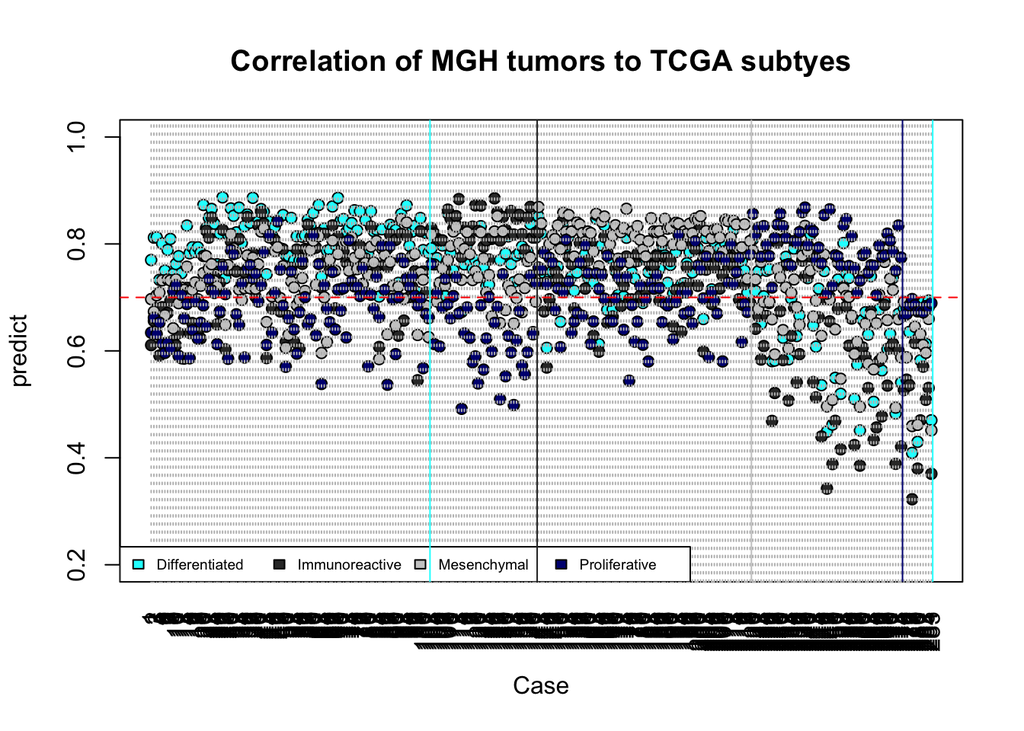

```r
tt<-plot.predict(pt)
title(main="Correlation of MGH tumors to TCGA subtyes")
```

## Comparing AOCS and TCGA classification.

The subtypes calls for the AOCS patients was published by Tothill, read the data

```r
supplClinAOCS<-read.csv(file.path(datadir, "18698038", "AOCSclinicaldata.csv"))
rownames(supplClinAOCS) = toupper(sub("\\.cel$", "",supplClinAOCS$X))
identical(rownames(supplClinAOCS),sampleNames(GSE9891_eset))
```

```
## [1] TRUE
```

```r
supplClinAOCS<-supplClinAOCS[sampleNames(GSE9891_eset),]
```

Cross-tabulation of TCGA subtypes and AOCS subtypes.

```r
table(pt$Predict,supplClinAOCS$k.means.Group)
```

```
##
##                   1  2  3  4  5  6 NC
##   Differentiated  5 18 27 36  0  2 14
##   Immunoreactive  5 27  0  3  0  0  4
##   Mesenchymal    67  4  0  0  0  0  7
##   Proliferative   6  1  0  6 33  1  8
##   Unclassified    0  0  1  1  3  5  1
```

# Predicting OVCA molecular subtype background

Gene lists that predict AOCS molecular and TCGA subtypes were downloaded as online publication supplements (Tothill et al. 2008,Verhaak et al. (2013)) curated and submitted to GeneSigDB (Culhane et al. 2012).

In this code, we downloaded the genelists and use a simple single sample predictor (SSP) approachfor classification (Haibe-Kains et al. 2012; Perou et al. 2000). Tumors are classified as a molecular subtype, if a tumor had highest Spearman correlation to the median gene expression profile of the subtype, compared to the correlation to the median gene expression of the other subtypes.

## The AOCS molecular subtypes: building a classifier

The AOCS data is available as GSE9891_eset in the curatedOvarianData package, where features are GeneSymbols. In the case below, we downloaded it from GEO as I wanted probeIDs are features. However the map strategdy can be used to generate a classifier from GSE9891_eset

```r
#Load AOCS (probeset) data
load(file.path(datadir,'AOCS_eSet.RData'))
tothill<-read.csv(file.path(datadir,"18698038", "18698038-TableS2.txt"), sep="\t", header=TRUE, as.is=TRUE)
AOCS_sig<-tothill[tothill[,1]%in%featureNames(aocs_eSet),]
aocs.sig=unique(AOCS_sig[,1])
if (!file.exists(file.path(datadir,"AOCS_Classifier_TothillGenes.Rda"))) {
  aocs.scm<-build.aocs(aocs_eSet, aocs.sig)
  save(aocs.scm,aocs.sig,file=file.path(datadir,"AOCS_Classifier_TothillGenes.Rda"))
}
```

```r
load(file.path(datadir,"AOCS_Classifier_TothillGenes.Rda"))
```

The Single Sample Predictor (SSP) classifier was trained using the published gene lists of the AOCS C1, C2, C4 and C5 molecular subtypes. The SSP identifies the subtype of a single tumor using a nearest centroid classifier and has been widely applied in molecular subtype classification in breast cancer (Haibe-Kains et al. 2012; Perou et al. 2000). It predicted the AOCS molecular subtypes with an overall **self-validation accuracy** of 95%. Sensitivity and specificityfor each subtype were is given below.

```r
aocsPredict<-predict.aocs(eSet=aocs_eSet, aocs.model=aocs.scm, corThres=0.7)
#table(factor(aocsPredict$Predict), factor(aocs_eSet$k.means.Group))
#table(factor(aocs_eSet$MS), factor(aocs_eSet$k.means.Group))
print(confusionMatrix(factor(aocsPredict$Predict), factor(aocs_eSet$MS, levels=levels(factor(aocsPredict$Predict)))))
```

```
## Confusion Matrix and Statistics
##
##               Reference
## Prediction     C1 C2 C4 C5 Unclassified
##   C1           68  2  0  1            0
##   C2            3 41  2  0            0
##   C4            0  0 32  0            0
##   C5            2  0  0 31            0
##   Unclassified  0  0  0  0            0
##
## Overall Statistics
##
##                Accuracy : 0.9451
##                  95% CI : (0.9013, 0.9733)
##     No Information Rate : 0.4011
##     P-Value [Acc > NIR] : < 2.2e-16
##
##                   Kappa : 0.9236
##  Mcnemar's Test P-Value : NA
##
## Statistics by Class:
##
##                      Class: C1 Class: C2 Class: C4 Class: C5
## Sensitivity             0.9315    0.9535    0.9412    0.9688
## Specificity             0.9725    0.9640    1.0000    0.9867
## Pos Pred Value          0.9577    0.8913    1.0000    0.9394
## Neg Pred Value          0.9550    0.9853    0.9867    0.9933
## Prevalence              0.4011    0.2363    0.1868    0.1758
## Detection Rate          0.3736    0.2253    0.1758    0.1703
## Detection Prevalence    0.3901    0.2527    0.1758    0.1813
## Balanced Accuracy       0.9520    0.9588    0.9706    0.9777
##                      Class: Unclassified
## Sensitivity                           NA
## Specificity                            1
## Pos Pred Value                        NA
## Neg Pred Value                        NA
## Prevalence                             0
## Detection Rate                         0
## Detection Prevalence                   0
## Balanced Accuracy                     NA
```

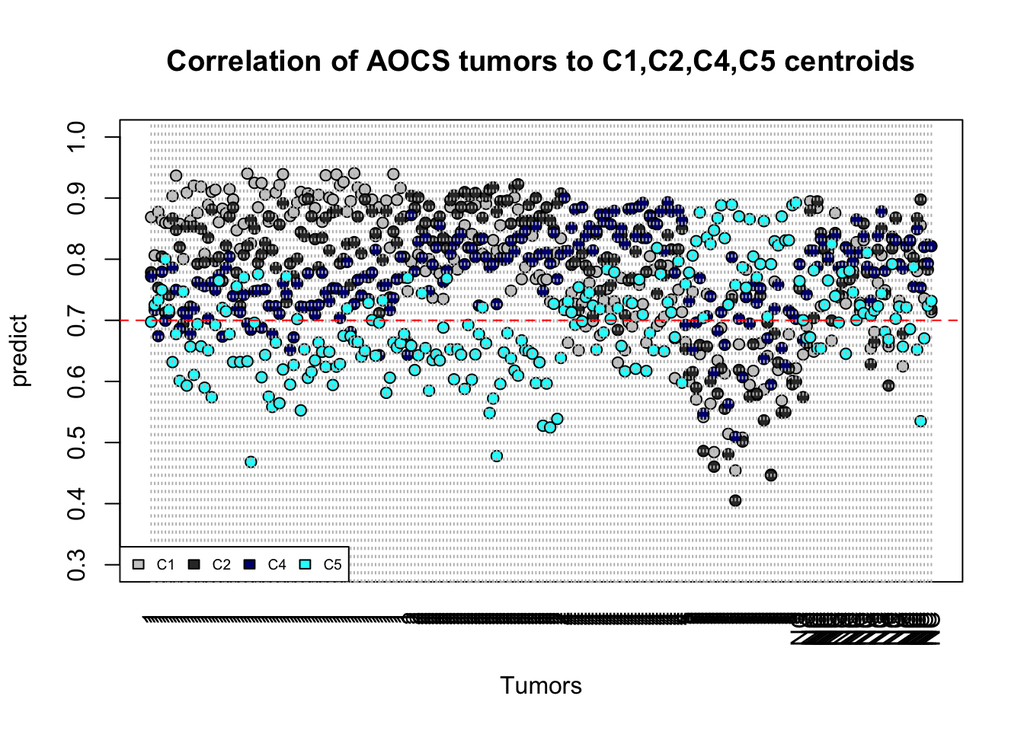

```r
n=nrow(aocsPredict[order(aocs_eSet$MS),])

plot.predict(aocsPredict[order(aocs_eSet$MS),], reorderByClass = FALSE, colLab=aocs_eSet$k.means.Group[order(aocs_eSet$MS)], xlab="Tumors")
title(main="Correlation of AOCS tumors to C1,C2,C4,C5 centroids")
```

In each case tumors are assigned to the subtype centroid to which it has highest correlation. Where there was no “winner”, tumors has low correlation to all subtypes (cor<0.7), it was unclassfied.

```r
aocsPredict[aocsPredict$Predict=="Unclassified",]
```

```
##                  C1        C2        C4        C5      Predict
## GSM249918 0.6572696 0.5931758 0.6646342 0.6685673 Unclassified
##           PredictPosteriorProb
## GSM249918                   NA
```

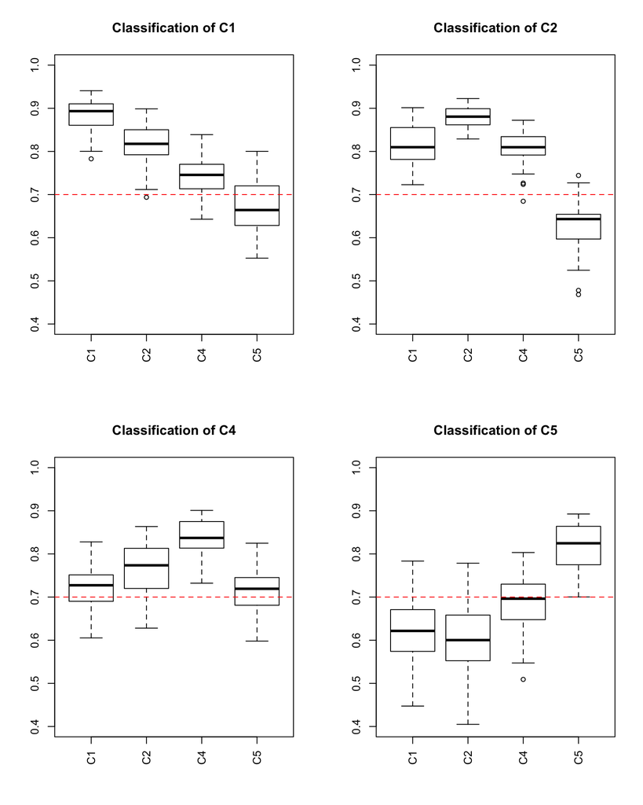

```r
par(mfrow=c(2,2))
for (i in colnames(aocsPredict)[1:4]) {boxplot(aocsPredict[aocsPredict$Predict==i,1:4], main=paste0("Classification of ",i ), las=3,ylim=c(0.4,1)); abline(h=0.7,lty=2,col="red" )}
```

It can be seens that C1 and C2 tumors, showed weaker correlation but >0.7 correlation to C1,C2 and C4 tumors. C1 and C2 tumors had lowest correlation to C5 tumors. Consistent with this, C5 were easier to classify, and mostly had <0.7 correlation to C1,C2,C4. This was reflect in the confusious matrix above, were C5 tumors were classified with the higher Balanced Accuracy (0.98), Sensitivity (0.97) and Specificity (0.99).

## AOCS molecular subtypes in curatedOvarianData

Example of applying classifiers to public data

```r
require(curatedOvarianData)
testaocsPredict<-predict.aocs(Tumors, aocs.model=aocs.scm,corThres=0.7)

#Plot of results
plot.predict(testaocsPredict, colLab=Tumors$alt_sample_name, xlab="Tumors")
```

[output not shown]

“Comprehensive Molecular Portraits of Human Breast Tumours.” 2012. *Nature* 490 (7418): 61–70.

Culhane, A. C., M. S. Schroder, R. Sultana, S. C. Picard, E. N. Martinelli, C. Kelly, B. Haibe-Kains, et al. 2012. “GeneSigDB: A Manually Curated Database and Resource for Analysis of Gene Expression Signatures.” *Nucleic Acids Res* 40 (Database issue): D1060–6.

Ganzfried, B. F., M. Riester, B. Haibe-Kains, T. Risch, S. Tyekucheva, I. Jazic, X. V. Wang, et al. 2013. “CuratedOvarianData: Clinically Annotated Data for the Ovarian Cancer Transcriptome.” *Database (Oxford)* 2013: bat013.

Haibe-Kains, B., C. Desmedt, S. Loi, A. C. Culhane, G. Bontempi, J. Quackenbush, and C. Sotiriou. 2012. “A Three-Gene Model to Robustly Identify Breast Cancer Molecular Subtypes.” *J Natl Cancer Inst* 104 (4): 311–25.

Perou, C. M., T. Sorlie, M. B. Eisen, M. van de Rijn, S. S. Jeffrey, C. A. Rees, J. R. Pollack, et al. 2000. “Molecular Portraits of Human Breast Tumours.” *Nature* 406 (6797): 747–52.

Tothill, R. W., A. V. Tinker, J. George, R. Brown, S. B. Fox, S. Lade, D. S. Johnson, et al. 2008. “Novel Molecular Subtypes of Serous and Endometrioid Ovarian Cancer Linked to Clinical Outcome.” *Clin Cancer Res* 14 (16): 5198–5208.

Verhaak, R. G., P. Tamayo, J. Y. Yang, D. Hubbard, H. Zhang, C. J. Creighton, S. Fereday, et al. 2013. “Prognostically Relevant Gene Signatures of High-Grade Serous Ovarian Carcinoma.” *J Clin Invest* 123 (1): 517–25.